# Contador de celulas

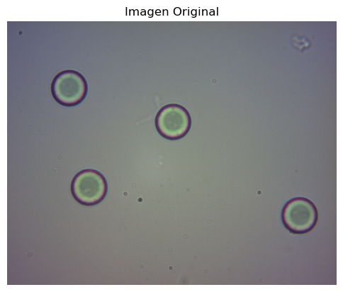

```python
# Importar librerías y cargar la imagen

import cv2
import numpy as np
import matplotlib.pyplot as plt
import pandas as pd
from scipy.spatial.distance import euclidean

# Cargar la imagen desde el repositorio
image_path = "PMMA15_T01.png"  # Asegúrate de que el archivo esté en el mismo directorio
image = cv2.imread(image_path)

# Convertir la imagen a escala de grises
gray = cv2.cvtColor(image, cv2.COLOR_BGR2GRAY)

# Mostrar la imagen original
plt.figure(figsize=(6,6))
plt.imshow(cv2.cvtColor(image, cv2.COLOR_BGR2RGB))
plt.axis("off")
plt.title("Imagen Original")
plt.show()
```

En este paso se importan las librerías necesarias y se carga la imagen de referencia. La imagen se convierte a escala de grises, lo que facilita la detección de bordes y reduce la cantidad de información innecesaria para el análisis. Se muestra la imagen original para verificar que se haya cargado correctamente.

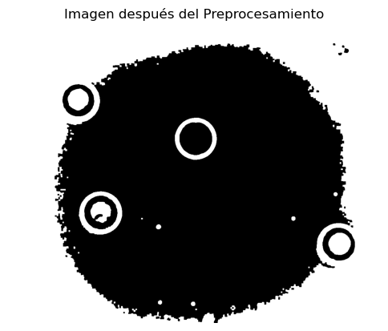

```python
# Preprocesamiento de la imagen

# Aplicar filtro Gaussiano para reducir el ruido
blurred = cv2.GaussianBlur(gray, (5,5), 0)

# Aplicar umbralización manual (basado en el histograma de intensidades)
manual_thresh = 120
_, binary_thresh = cv2.threshold(blurred, manual_thresh, 255, cv2.THRESH_BINARY_INV)

# Aplicar operaciones morfológicas para mejorar la segmentación
kernel = np.ones((3,3), np.uint8)
morph_open = cv2.morphologyEx(binary_thresh, cv2.MORPH_OPEN, kernel, iterations=2)
morph_close = cv2.morphologyEx(morph_open, cv2.MORPH_CLOSE, kernel, iterations=2)

# Mostrar la imagen umbralizada
plt.figure(figsize=(6,6))
plt.imshow(morph_close, cmap='gray')
plt.axis("off")
plt.title("Imagen después del Preprocesamiento")
plt.show()
```

Las células aparecen rodeadas por un contorno más oscuro debido a la forma en que la luz atraviesa la muestra en el microscopio. Este contraste es útil para segmentarlas, pero también puede generar falsos bordes internos, por lo que es necesario refinar la detección en los pasos siguientes.

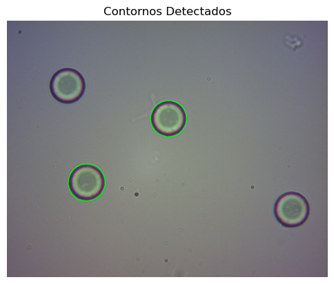

```python
# Segmentación y detección de contornos

# Detectar contornos en la imagen procesada
contours, _ = cv2.findContours(morph_close, cv2.RETR_EXTERNAL, cv2.CHAIN_APPROX_SIMPLE)

# Filtrar contornos por área para evitar detectar ruido
min_area = 500
max_area = 20000
filtered_contours = [cnt for cnt in contours if min_area < cv2.contourArea(cnt) < max_area]

# Dibujar los contornos detectados en la imagen original
contour_image = image.copy()
cv2.drawContours(contour_image, filtered_contours, -1, (0, 255, 0), 2)

# Mostrar la imagen con contornos
plt.figure(figsize=(6,6))
plt.imshow(cv2.cvtColor(contour_image, cv2.COLOR_BGR2RGB))
plt.axis("off")
plt.title("Contornos Detectados")
plt.show()
```

Este bloque se encarga de encontrar los bordes de las células en la imagen umbralizada. Se usa cv2.findContours(), que detecta los objetos en la imagen en función de sus diferencias de intensidad. Para evitar que se detecte ruido, se filtran los contornos según su área: solo se conservan los que tienen un tamaño dentro de un rango razonable, descartando puntos pequeños y objetos demasiado grandes que puedan ser artefactos de la imagen.

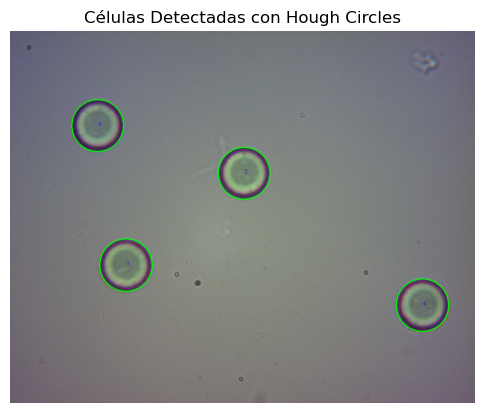

```python
# Detección de células con Transformada de Hough

# Aplicar la Transformada de Hough para detectar círculos
detected_circles = cv2.HoughCircles(
    gray, cv2.HOUGH_GRADIENT, dp=1.2, minDist=50,
    param1=50, param2=30, minRadius=20, maxRadius=100
)

# Filtrar y fusionar células superpuestas
filtered_results = []
merged_centers = []

if detected_circles is not None:
    detected_circles = np.uint16(np.around(detected_circles))
    for circle in detected_circles[0, :]:
        x, y, radius = circle
        area = np.pi * (radius ** 2)
        perimeter = 2 * np.pi * radius
        diameter = 2 * radius

        # Verificar si el círculo se superpone con otro
        merged = False
        for j, (cx, cy, cr) in enumerate(merged_centers):
            distance = euclidean((x, y), (cx, cy))
            if distance < min(cr, radius) * 0.7:
                if radius > cr:
                    merged_centers[j] = (x, y, radius)
                merged = True
                break

        if not merged:
            merged_centers.append((x, y, radius))

# Dibujar los círculos detectados en la imagen
output_image = image.copy()
for i, (x, y, radius) in enumerate(merged_centers):
    cv2.circle(output_image, (x, y), radius, (0, 255, 0), 2)
    cv2.putText(output_image, f"{i+1}", (x, y),
                cv2.FONT_HERSHEY_SIMPLEX, 0.5, (255, 0, 0), 1)

# Mostrar la imagen con las células detectadas
plt.figure(figsize=(6,6))
plt.imshow(cv2.cvtColor(output_image, cv2.COLOR_BGR2RGB))
plt.axis("off")
plt.title("Células Detectadas con Hough Circles")
plt.show()
```

En este paso se utiliza la Transformada de Hough, un algoritmo que permite detectar círculos en una imagen. Este método es útil porque las células son prácticamente circulares, lo que lo hace más preciso que solo usar contornos.

La idea es analizar la imagen en busca de patrones circulares en función de sus bordes y contrastes. El algoritmo toma como entrada la imagen en escala de grises y busca combinaciones de píxeles que formen un círculo, basándose en un conjunto de parámetros como el tamaño mínimo y máximo esperado. En este caso, los parámetros dp, minDist, param1 y param2 se ajustan para evitar detecciones erróneas y asegurarse de que solo se identifiquen células reales.

```python
# Visualización y Exportación de Resultados

# Crear DataFrame con la información de las células detectadas
results_df = pd.DataFrame([
    {"Celula": i + 1, "Área (px²)": np.pi * (r ** 2), "Perímetro (px)": 2 * np.pi * r,
     "Diámetro (px)": 2 * r, "Radio (px)": r, "Centroide X": x, "Centroide Y": y}
    for i, (x, y, r) in enumerate(merged_centers)
])

# Mostrar DataFrame con resultados
import IPython.display as display
display.display(results_df)

# Exportar los resultados a un archivo CSV
results_df.to_csv("resultados_celulas.csv", index=False)
print("Los resultados se han guardado en 'resultados_celulas.csv'")
```

|  | Celula | Área (px²) | Perímetro (px) | Diámetro (px) | Radio (px) | Centroide X | Centroide Y |
| --- | --- | --- | --- | --- | --- | --- | --- |
| 0 | 1 | 16286.016316 | 452.389342 | 144 | 72 | 319 | 645 |
| 1 | 2 | 15836.768567 | 446.106157 | 142 | 71 | 644 | 393 |
| 2 | 3 | 15836.768567 | 446.106157 | 142 | 71 | 241 | 262 |
| 3 | 4 | 16286.016316 | 452.389342 | 144 | 72 | 1135 | 755 |

```
Los resultados se han guardado en 'resultados_celulas.csv'
```

Aquí se organiza la información de cada célula en un DataFrame, que contiene valores como área, perímetro, diámetro y centroide en píxeles. Luego, estos datos se exportan a un archivo CSV para análisis posterior.